# Data Visualization with ggplot2

## Agenda

- Grammar of Graphics
- ggplot2 examples
- Graphics for communication
- Readings: R4DS Chapters 3, 5, 7, and 28
- Other sources:
  - [Quick-R Data Management](https://www.statmethods.net/management/index.html)
  - [Quick-R Data Input](https://www.statmethods.net/input/index.html)

## ggplot2 package

`ggplot2` functions are a bit more complex than R’s basic plotting commands in many cases, but have a more consistent formatting

- There are whole books devoted to this package! (http://ggplot2.org/book)
- There are whole graduate-level courses devoted to data visualization!
- Many researchers still use base R graphics for exploratory data analysis
- ggplot2 graphics are great for showing other people

R will load the `ggplot2` package when loading the `tidyverse` package (which we’ll be using extensively)

## The Grammar of Graphics

Grammar of language – rules of structuring words and phrases into meaningful expressions

Grammar of graphics – rules of structuring mathematic and aesthetic elements into a meaningful graph

- **Data** are variables mapped to aesthetic features
- **Geoms** are the objects/shapes on the graph
- **Stats** are statistical transformations that summarize data
- **Scales** define which aesthetic values are mapped to data values (legends. axes)
- **Coordinate systems** define the plane on which data are mapped
- **Faceting** splits the data into subsets to create variations of same graph

## Example Dataset: US Murders

```r
#install.packages("tidyverse")
#install.packages("dslabs")
library(tidyverse)
library(dslabs)
data(murders)
head(murders)
##        state abb region population total
## 1    Alabama  AL  South    4779736   135
## 2     Alaska  AK   West     710231    19
## 3    Arizona  AZ   West    6392017   232
## 4   Arkansas  AR  South    2915918    93
## 5 California  CA   West   37253956  1257
## 6   Colorado  CO   West    5029196    65
```

## ggplot objects

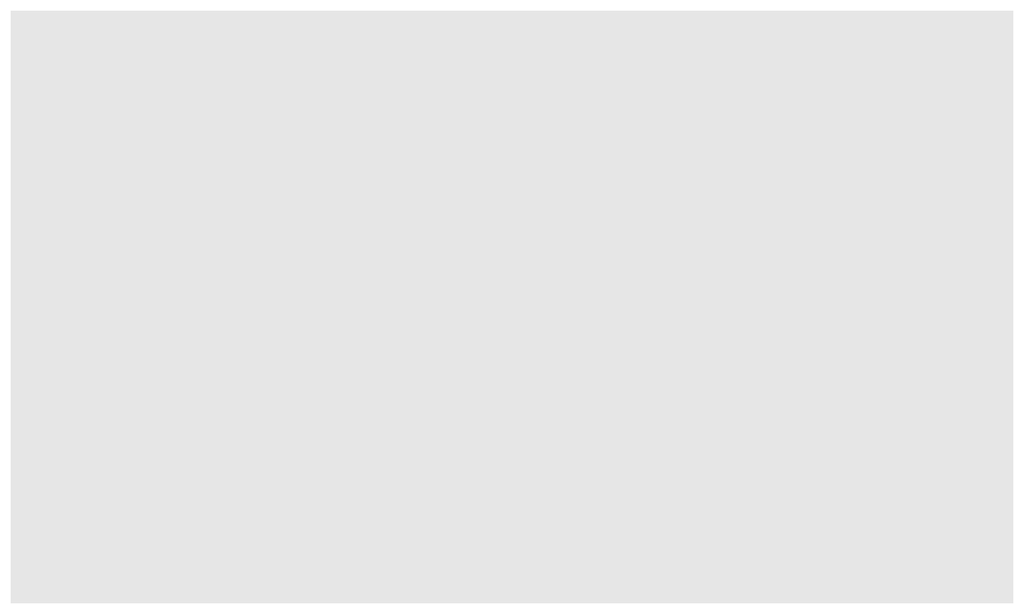

```r
ggplot(data = murders)
```

```r
# murders %>% ggplot() # equivalent
```

## ggplot objects

```r
p <- ggplot(data = murders)
class(p)
## [1] "gg"     "ggplot"
# print(p) # equivalent to ggplot(data=murders)
```

## Geometries

Geom functions produce the graphical rendering

Geoms each require/understand different aesthetics

## geom_point

- The help files for each geom are useful for determining which aesthetics are expected.
- For `geom_point`, we can specify:
  - `x` (required)
  - `y` (required)
  - `alpha`
  - `colour`

## Aesthetic mappings

- Aesthetic mappings describe how properties of the data connect with features of the graph
  - e.g., distance along the axis, size, color
  - `aes` function is the primary tool, and has some nice features (like recognizing variable names in the data file)

```r
murders %>% ggplot() +
  geom_point(mapping = aes(x = population/10^6, y = total, color=region)) #note that mapping=, x=, and y= aren't needed, but good practice
```

## Aesthetic mappings

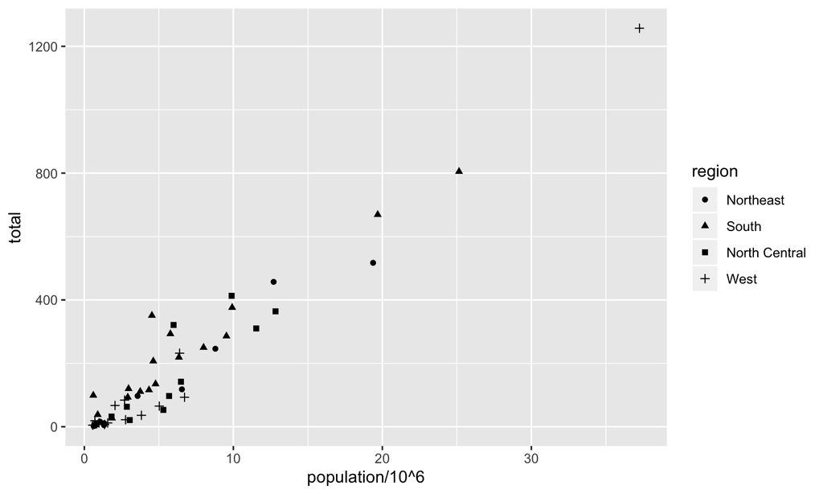

```r
murders %>% ggplot() +
  geom_point(mapping = aes(x = population/10^6, y = total, shape=region)) #note that mapping=, x=, and y= aren't needed, but good practice
```

- Be careful with `shape`: by default, only the first 6 categories will be get shapes

## Layers

- We can add additional layers to our plots, just like we added the `geom_point` layer
- Suppose we wanted to add labels to our plot
  - `geom_label` and `geom_text` add text to the plot, with or without background rectanges (respectively)

## Layers

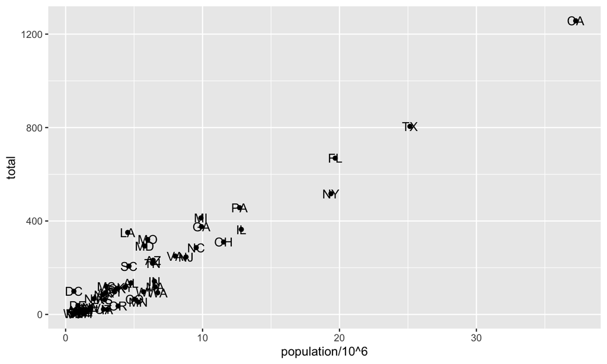

```r
p <- murders %>% ggplot()
p + geom_point(aes(population/10^6, total)) +
  geom_text(aes(population/10^6, total, label = abb))
```

```r
# p_test <- p + geom_text(aes(population/10^6, total), label = abb)
# Why does this return an error?
```

## Layers

- We can add in other options, like `size` and `nudge_x`.
- If the options affect all points the same, they are defined outside of `aes()`

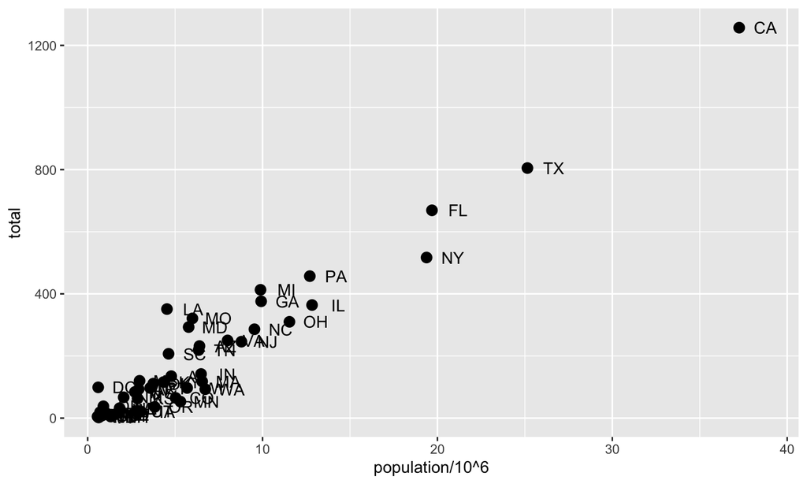

```r
p + geom_point(aes(population/10^6, total), size = 3) +
  geom_text(aes(population/10^6, total,label = abb), nudge_x = 1.5)
```

## Layers

We can define aesthetic mappings in the original `ggplot` call, and added layers will inherit them:

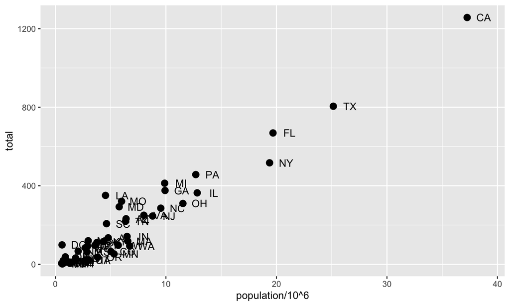

```r
p <- murders %>% ggplot(aes(population/10^6, total, label = abb))
p + geom_point(size = 3) +
  geom_text(nudge_x = 1.5)
```

```r
#size and nudge_x apply to the points and text separately, so we don't put them in the ggplot call
```

## Layers

If necessary, we can override the global mapping by defining a new mapping within each layer. These local definitions override the global. Here is an example:

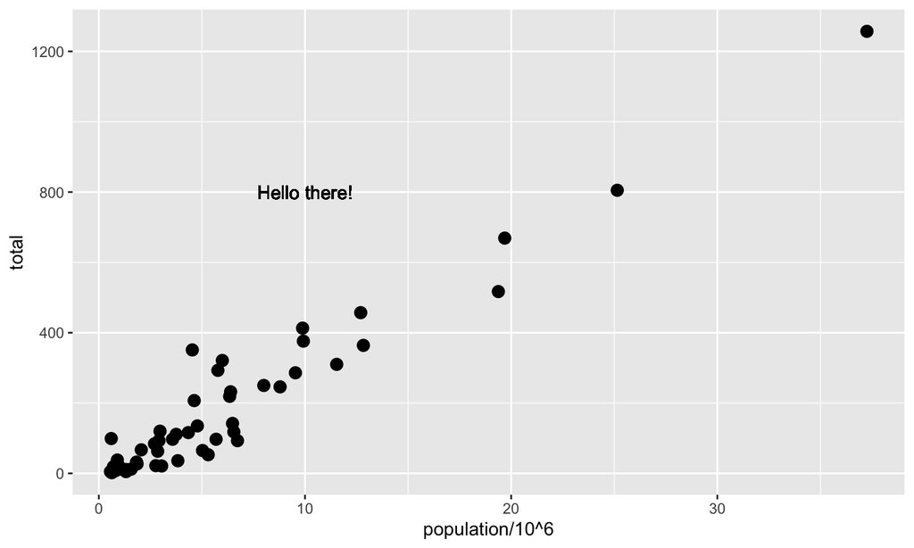

```r
p + geom_point(size = 3) +
  geom_text(aes(x = 10, y = 800, label = "Hello there!"))
```

## Scales

We can change the x and y scales using additional layers:

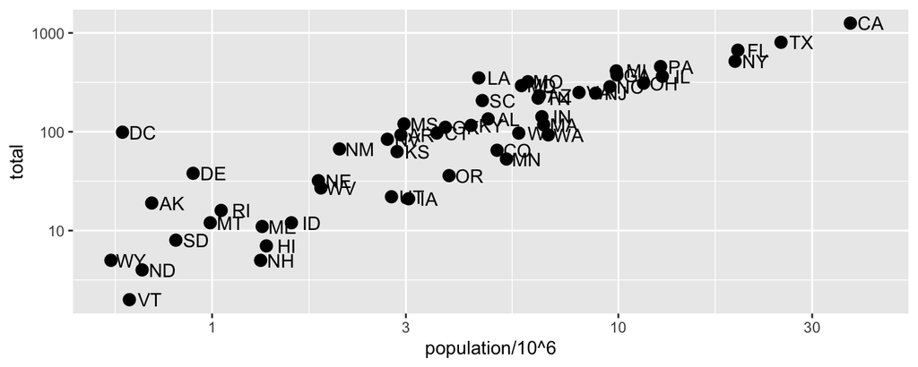

```r
p + geom_point(size = 3) +
  geom_text(nudge_x = 0.05) +
  scale_x_continuous(trans = "log10") +
  scale_y_continuous(trans = "log10")
```

## Scales

- log10 scales are built into ggplot2:

```r
p + geom_point(size = 3) +
  geom_text(nudge_x = 0.05) +
  scale_x_log10() +
  scale_y_log10()
```

## Labels and titles

- We can add labels and titles too:

```r
p + geom_point(size = 3) +
  geom_text(nudge_x = 0.05) +
  scale_x_log10() +
  scale_y_log10() +
  xlab("Populations in millions (log scale)") +
  ylab("Total number of murders (log scale)") +
  ggtitle("US Gun Murders in 2010")
```

## Labels and titles

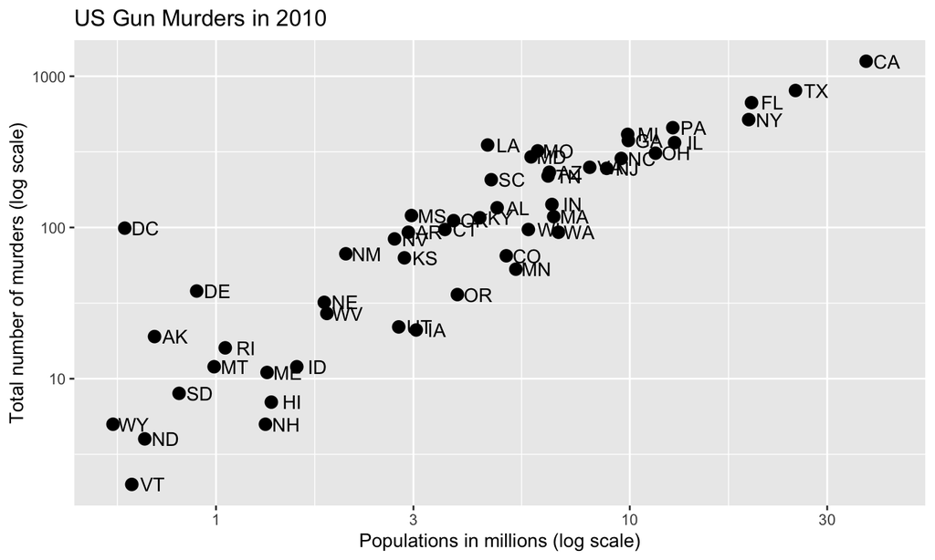

## Colors

```r
p + geom_point(aes(col=region), size = 3)
#Notes the difference from: p + geom_point(col="blue", size = 3)
```

## Colors

[figure not shown]

## Fix the legend title

```r
p + scale_color_discrete(name = "Region")
```

## Fix the legend title

[figure not shown]

## Themes

- The style of a ggplot2 graph can be changed using the theme functions.
- Several themes are included as part of the ggplot2 package, including:
  - `theme_gray`: default
  - `theme_bw`: classic dark-on-light
  - `theme_linedraw`: black lines on white background
  - `theme_light`: grey lines on white background
  - `theme_dark`: like `theme_light` but with a dark background
  - `theme_void`: “a completely empty theme”

## Themes

- We can access additional themes using the `ggthemes` package, including:

```r
library(ggthemes)
ls("package:ggthemes")[grepl("theme_", ls("package:ggthemes"))]
##  [1] "theme_base"            "theme_calc"
##  [3] "theme_clean"           "theme_economist"
##  [5] "theme_economist_white" "theme_excel"
##  [7] "theme_excel_new"       "theme_few"
##  [9] "theme_fivethirtyeight" "theme_foundation"
## [11] "theme_gdocs"           "theme_hc"
## [13] "theme_igray"           "theme_map"
## [15] "theme_pander"          "theme_par"
## [17] "theme_solarized"       "theme_solarized_2"
## [19] "theme_solid"           "theme_stata"
## [21] "theme_tufte"           "theme_wsj"
```

## Themes

```r
p + geom_point(aes(col=region), size = 3) +
  geom_text(nudge_x = 0.05) +
  scale_x_log10() +
  scale_y_log10() +
  xlab("Populations in millions (log scale)") +
  ylab("Total number of murders (log scale)") +
  ggtitle("US Gun Murders in 2010") +
  scale_color_discrete(name = "Region") +
  theme_economist()
```

## Themes

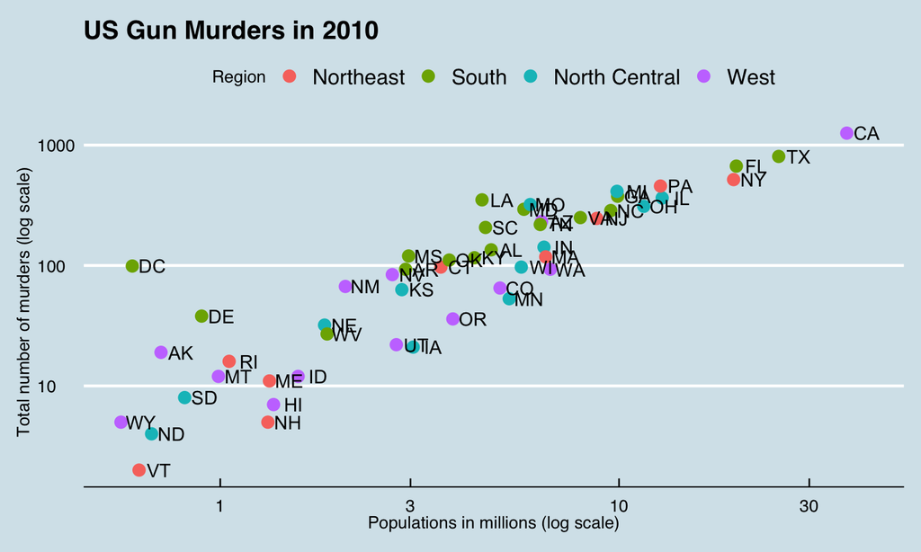

## Quick plots

Sometimes, we just want a quick plot. Enter `qplot`

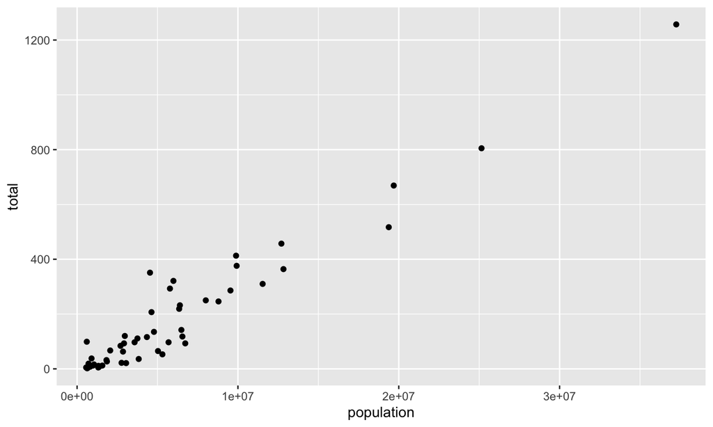

```r
qplot(population, total, data=murders)
```

## Quick plots

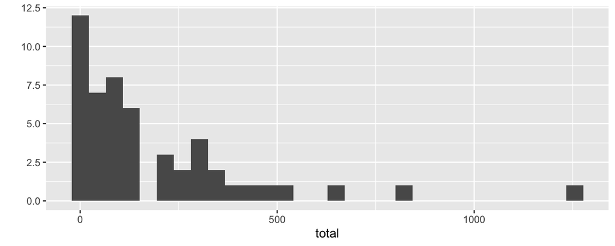

```r
qplot(total, data=murders)
```

```r
# murders %>% qplot(total, data=.)
# qplot(total, data=murders, geom="density")
# qplot(total, data=murders, color="blue")
```

## Grids of ggplots

We can even plot several graphs next to each other (or in a grid) with the `gridExtra` package:

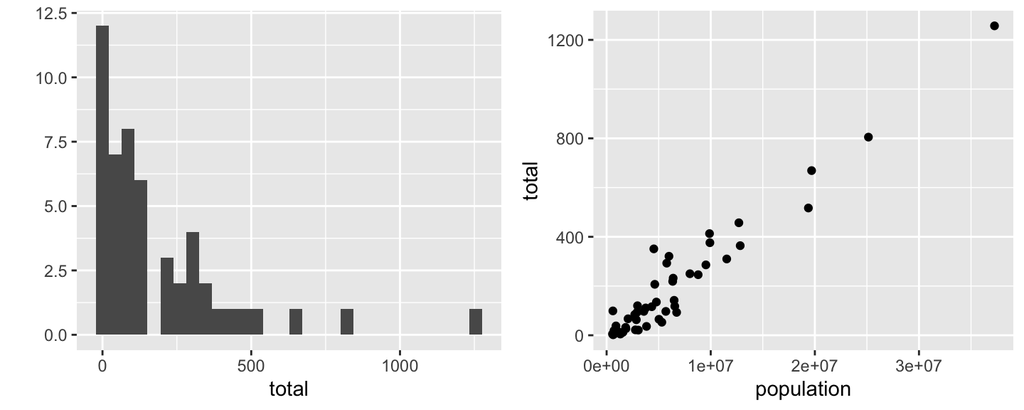

```r
library(gridExtra)
p1 <- qplot(total, data=murders)
p2 <- qplot(population, total, data=murders)
grid.arrange(p1, p2, ncol=2)
```

## Facets

We can make similar graphs, separated based on a variable, arranged in a grid, using facets.

- Use `facet_wrap()` to facet your plot by a single discrete variable

```r
ggplot(data=murders) +
  geom_point(mapping = aes(population/10^6, total)) +
  facet_wrap(~region, nrow=2)
```

## Facets

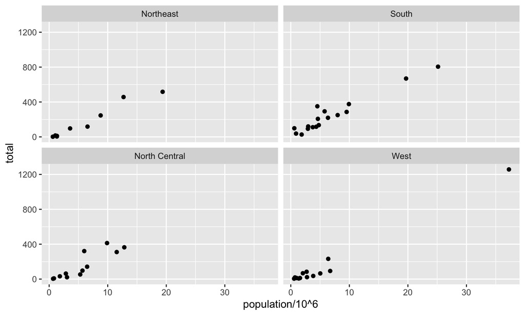

## Facets

- Use `facet_grid` to subset based on two discrete variables
  - convention is `rows ~ columns`

```r
#This is a dumb plot.
ggplot(data=murders) +
  geom_point(mapping = aes(population/10^6, total)) +
  facet_grid(state~region, nrow=2)
```

## Data visualization principles: visual cues

There are a few main visual cues to consider when making plots:

- position
- aligned lengths
- angles
- area
- brightness
- color hue

## Data visualization principles: when to include 0

Graphs based on aligned lengths (like bar charts) should include 0

[figure not shown]

## Data visualization principles: when to include 0

[figure not shown]

## Data visualization principles: when to include 0

When using position, rather than length, it’s not necessary to include 0

[figure not shown]

## Data visualization principles: don’t distort the data

[figure not shown]

## Data visualization principles: ordering categories with reorder()

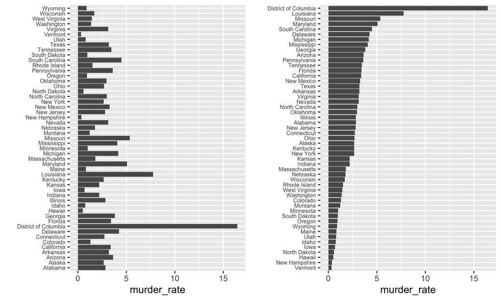

## Data visualization principles: ease comparisons

There are a few ways to make comparisons easier for your audience:

- Overlay the plots together (e.g., histograms and densities)
- Use common axes
- Align plots vertically to see horizontal changes and horizontally to see vertical changes

## Data visualization principles: ease comparisons

[figure not shown]

## Data visualization principles: adjacent cues

Visual cues to be compared should be adjacent.

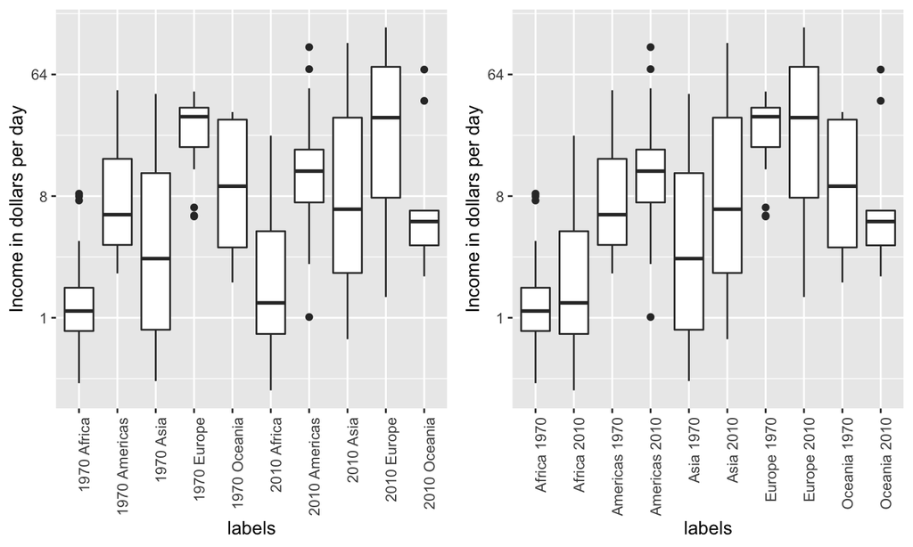

## Data visualization principles: colors

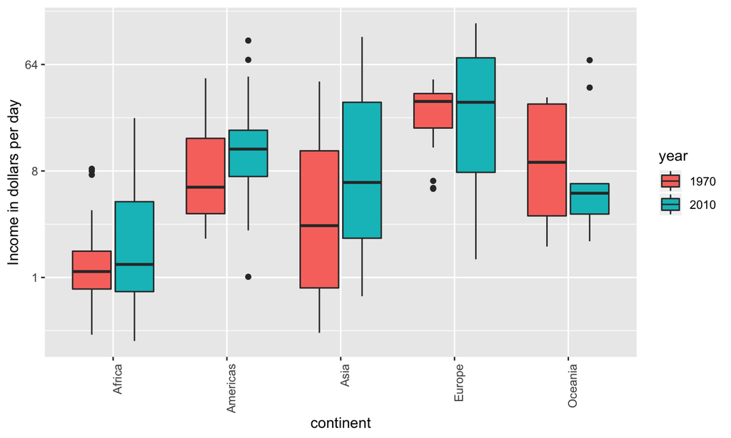

## Data visualization principles: colorblind

```r
color_blind_friendly_cols <-
  c("#999999", "#E69F00", "#56B4E9", "#009E73",
    "#F0E442", "#0072B2", "#D55E00", "#CC79A7")
```

Here are the colors:

[figure not shown]

- More info:
  - http://bconnelly.net/2013/10/creating-colorblind-friendly-figures/
  - `ggthemes` package, using `colorblind_pal()`, `scale_color_colorblind(...)`, and `scale_fill_colorblind(...)`

## Data visualization principles: two variables

Comparing variables of the same type, but at different time points and for a relatively small number of comparisons: the *slope chart*.

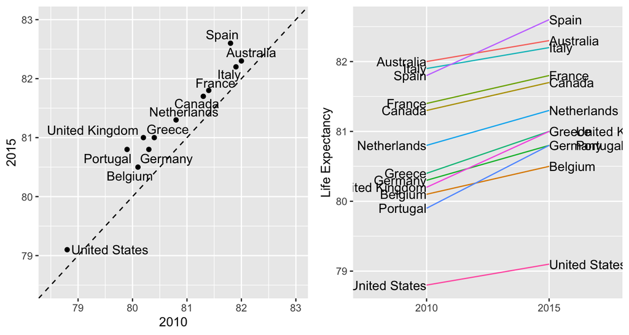

## Data visualization principles: two variables

If the difference in years is the most important, devote an axis to it!

Since we are primarily interested in the difference, it makes sense to dedicate one of our axes to it. The Bland-Altman plot, also known as the Tukey mean-difference plot and the MA-plot, shows the difference versus the average:

## Data visualization principles: Bland-Altman plot

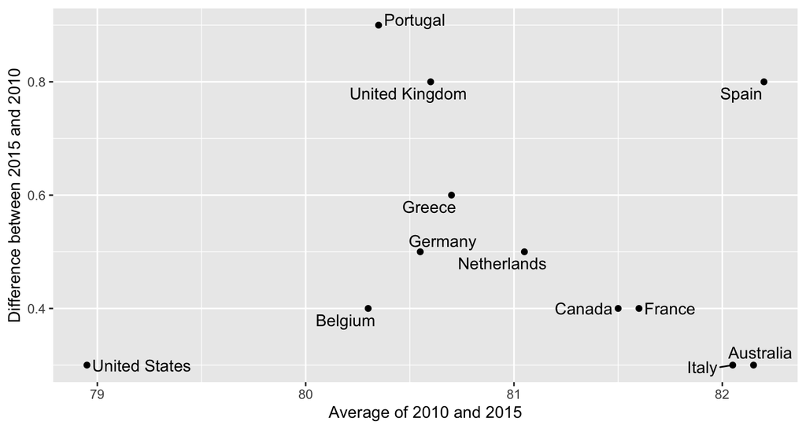

## Data visualization principles: encoding a third variable

- We can give information about a third numeric variable using color or size (categorical with color or shape)
- When considering colors, we have “sequential”, “divergent”, and “qualitative” palettes built into ggplot2
  - Sequential: good for values that go low to high
  - Divergent: values diverge from a center, equal emphasis on both sides
  - Qualitative: a collection of colors that look “nice” together
  - (self-defined options exist, like the colorblind palettes)
- There are a LOT more options: see [ggplot2 reference](https://ggplot2.tidyverse.org/reference/scale_brewer.html)

## Extensions to ggplot2

- `factoextra`: extract and visualize outputs of a multivariate analysis
- `easyggplot2`: perform and easily customize ggplots
- `ggfortify`: allow ggplot2 to handle some popular R packages
- `GGally`: correlation matrices, scatterplot matrices, networks
- `ggRandomForests`: graphics for random forests
- `ggdendro`: dendrograms

## Extensions to ggplot2

- `ggmcmc`: tools for MCMC simulations
- `ggeasy`: quick access to tweak commonly used ggplot2 theme settings
- `patchwork`: more approaches to multi-plot layouts
- `cowplot`: publication-ready theme formats
- `gghighlight`: highlights ggplot2 geoms that match a given predicate
- `ggridges`: better visualizations of multiple densities

## Other cool tips

- You can use %+% to change datasets: `plot2 <- plot1 %+% different_data`